# Project - Concrete Strength Prediction

- Amarpreet Bassan

**Assumptions**

1. The machine has [PPS](https://github.com/8080labs/ppscore#installation) package installed.
2. The machine has missingno package installed.
3. The machine has anaconda installed.
4. The data file : concrete.csv is in teh same folder.
1. Import Section
2. Dataset Import - Analytical Base Table
3. Univariate Analysis
   - **Univariate Analysis Observation**
4. Bivariate Analysis
   - Predictive Power Score
     - PPS - Observation
   - Variance Inflation Factor
     - VIF Observation
   - Pair Plot
     - Pair Plot Observation
   - **Bivariate Analysis Observation**
5. Feature Engineering
   - **Feature Engineering End Result**
6. Model Creation and Tuning
   - Introduction
   - Polynomial Regression Function
   - Decision Tree Regressor Function
   - Bagging Regression Function
   - Boosing Regression Function
   - **Main Function for Model Creation and Tuning**
     - Main Function Introduction
7. **R2 Score , The best Model and the Observation**

### Import Section

Table Of Contents

```python
#importing pandas library
import pandas as pd
#importing numpy library
import numpy as np
#import matplolib library
import matplotlib.pyplot as plt
#import seaborn library
import seaborn as sns
#set color codes to true
sns.set(color_codes=True)
#changing the formatting of the float variables
pd.options.display.float_format = '{:.4f}'.format

#changing the width of the jupyter notebook
from IPython.core.display import display, HTML
display(HTML('<style>.container {width: 95%  !important}</style>'))

#import all the metrics related to model selection
from sklearn.metrics import accuracy_score, f1_score, roc_auc_score, r2_score, precision_score, recall_score

#import all the capabilities of model_selection
from sklearn.model_selection import cross_val_score, train_test_split, GridSearchCV, RandomizedSearchCV

#import all the capabilities of yellowbrick target class
from yellowbrick.target import FeatureCorrelation, ClassBalance

#import all the capabilities of yellowbrick classifier class
from yellowbrick.classifier import ROCAUC, PrecisionRecallCurve, ClassificationReport

#import missingno
import missingno as msno

#import pps - predictive power score
import ppscore as pps


#import the skelarn libraries

from sklearn.preprocessing import PolynomialFeatures
from sklearn.pipeline import make_pipeline
from sklearn.pipeline import Pipeline
from sklearn.linear_model import LinearRegression
from sklearn.model_selection import GridSearchCV
from sklearn.tree import DecisionTreeRegressor
#Bagging for Decision Tree

from sklearn.ensemble import BaggingRegressor
from sklearn.ensemble import GradientBoostingRegressor

import re
```

### Dataset Import - Analytical Base Table

Table Of Contents

```python
#we import the dataset to form Analytical Base Table
abt = pd.read_csv("concrete.csv", header = 0)
```

```python
#make a working dataset
wdf = abt.copy()
```

### Univariate Analysis

Table Of Contents

#### DataTypes Investigation

Table Of Contents

```python
#lets look at various datatypes
wdf.info()
```

```
<class 'pandas.core.frame.DataFrame'>
RangeIndex: 1030 entries, 0 to 1029
Data columns (total 9 columns):
 #   Column        Non-Null Count  Dtype
---  ------        --------------  -----
 0   cement        1030 non-null   float64
 1   slag          1030 non-null   float64
 2   ash           1030 non-null   float64
 3   water         1030 non-null   float64
 4   superplastic  1030 non-null   float64
 5   coarseagg     1030 non-null   float64
 6   fineagg       1030 non-null   float64
 7   age           1030 non-null   int64
 8   strength      1030 non-null   float64
dtypes: float64(8), int64(1)
memory usage: 72.5 KB
```

##### Observation:

Table Of Contents

1. All of the datatypes are numeric.
2. There are no null values reported in the above command

```python
wdf.columns
```

```
Index(['cement', 'slag', 'ash', 'water', 'superplastic', 'coarseagg',
       'fineagg', 'age', 'strength'],
      dtype='object')
```

#### Distribution of Valuesn

Table Of Contents

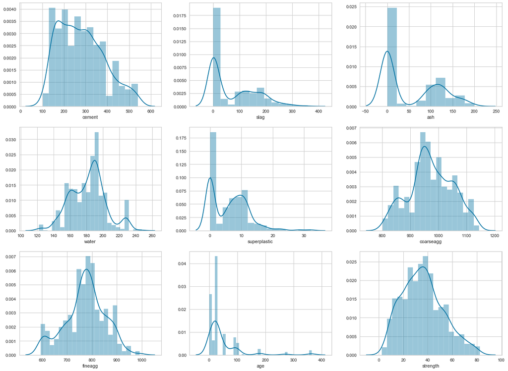

```python
#Lets get the distribution of values for each of these features

number_of_columns = len(wdf.columns)
plots_per_rows = 3
number_of_rows = int(np.ceil(number_of_columns/plots_per_rows))
columns_list = wdf.columns
colindex = 0
fig, axis = plt.subplots(figsize = (20, 15), nrows = number_of_rows, ncols = plots_per_rows)

for r in range(0,number_of_rows):
    for c in range(0,plots_per_rows):
        sns.distplot(wdf[columns_list[colindex]], ax = axis[r][c])
        colindex += 1
        if colindex >= len(columns_list):
            break
```

##### Observation:

Table Of Contents

#### Skewness Investigation

Table Of Contents

```python
#lets get the skewness value for each column:
wdf.skew(axis = 0, skipna = True)
```

```
cement          0.5095
slag            0.8007
ash             0.5374
water           0.0746
superplastic    0.9072
coarseagg      -0.0402
fineagg        -0.2530
age             3.2692
strength        0.4170
dtype: float64
```

##### Observation:

Table Of Contents

1. The observation matches with the above plots.

#### Missing Values Investigation

Table Of Contents

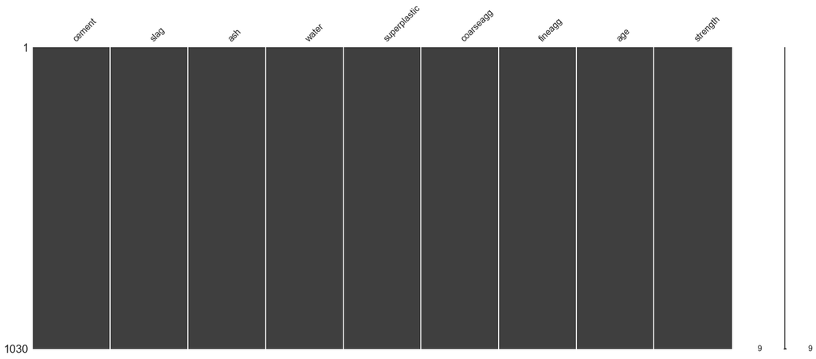

```python
#let us plot the missing valuesf
msno.matrix(wdf)
```

##### Observation:

Table Of Contents

No missing Values in any of the features.

#### Unique Values Investigation

Table Of Contents

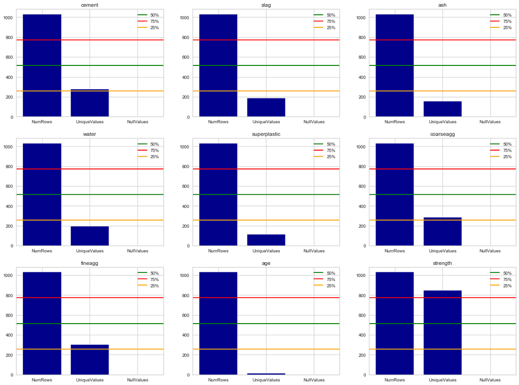

```python
columns_list = wdf.columns
df_duplicate = pd.DataFrame()
middle_row = wdf.shape[0] *.5

three_fourth_value = wdf.shape[0] * .75

firstquarter = wdf.shape[0] * .25

for colname in columns_list:
    column_length = wdf[colname].count()
    nunique_values= wdf[colname].nunique()
    null_values = wdf[colname].isnull().sum()
    df_duplicate[colname] = [column_length, nunique_values, null_values]

#rename indexes
df_duplicate = df_duplicate.rename(index = {0:'NumRows', 1:'UniqueValues', 2:'NullValues'})

index_values = ['NumRows', 'UniqueValues', 'NullValues']

number_of_columns = len(wdf.columns)
plots_per_rows = 3
number_of_rows = int(np.ceil(number_of_columns/plots_per_rows))

colindex = 0
fig, axis = plt.subplots(figsize = (20, 15), nrows = number_of_rows, ncols = plots_per_rows)

for r in range(0,number_of_rows):
    for c in range(0,plots_per_rows):
        axis[r][c].bar(index_values , df_duplicate[columns_list[colindex]], color = 'darkblue')
        axis[r][c].axhline(middle_row, color ='green', lw = 2 , label = '50%')
        axis[r][c].axhline(three_fourth_value, color = 'red', lw = 2, label = '75%')
        axis[r][c].axhline(firstquarter, color = 'orange', lw = 2, label = '25%')
        axis[r][c].legend(loc = 'upper right')
        axis[r][c].set_title(columns_list[colindex])
        colindex += 1
        if colindex >= len(columns_list):
            break
```

##### Observation:

Table Of Contents

1. Age has maximum duplication of data - this is evident in the above histogram to.
2. Strength has more than 75% unique values.
3. Courseagg, cement and fineagg has more than 25% unique values.
4. all the other features have less than 25% unique values.

### Univariate Analysis Observation

Table Of Contents

Consider the following :

1. Normalization technique to remove the skewness from the columns.
2. Age is highly imbalanced. we might have to investigate the correlation and VIF.

### Bivariate Analysis

Table Of Contents

#### Predictive Power Score

Table Of Contents

Predictive power score is being used because of the following :

1. Correlation will only give relationship between numerical values.
2. PPS helps find relationship between features whether numeric or catagorical.

```python
pps_df = pps.matrix(wdf).pivot(columns = 'x', index = 'y', values = 'ppscore')
pps_df
```

| x y | age | ash | cement | coarseagg | fineagg | slag | strength | superplastic | water |
| --- | --- | --- | --- | --- | --- | --- | --- | --- | --- |
| age | 1.0000 | 0.0000 | 0.0000 | 0.0000 | 0.0000 | 0.0000 | 0.0000 | 0.0000 | 0.0000 |
| ash | 0.1723 | 1.0000 | 0.7127 | 0.7772 | 0.7303 | 0.3120 | 0.0000 | 0.6036 | 0.6411 |
| cement | 0.0502 | 0.3698 | 1.0000 | 0.5733 | 0.6145 | 0.4792 | 0.0529 | 0.2988 | 0.4378 |
| coarseagg | 0.0418 | 0.3063 | 0.5853 | 1.0000 | 0.6991 | 0.3832 | 0.0000 | 0.2897 | 0.4899 |
| fineagg | 0.0278 | 0.2339 | 0.6010 | 0.6632 | 1.0000 | 0.4011 | 0.0000 | 0.2027 | 0.5150 |
| slag | 0.0091 | 0.2174 | 0.6617 | 0.6165 | 0.6756 | 1.0000 | 0.0000 | 0.1416 | 0.3890 |
| strength | 0.2280 | 0.0189 | 0.1482 | 0.1169 | 0.0956 | 0.1000 | 1.0000 | 0.0410 | 0.1179 |
| superplastic | 0.2203 | 0.3041 | 0.6945 | 0.6883 | 0.7311 | 0.4329 | 0.0099 | 1.0000 | 0.7273 |
| water | 0.1366 | 0.3205 | 0.6655 | 0.6397 | 0.7214 | 0.4354 | 0.0000 | 0.4582 | 1.0000 |

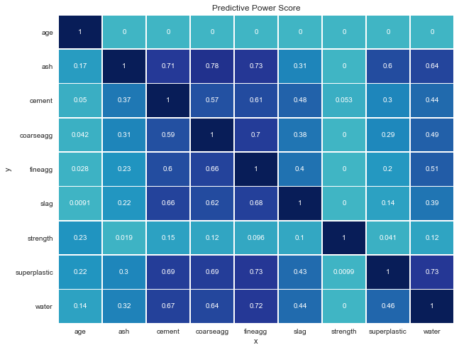

```python
plt.figure(figsize=(10,8))

ax = plt.axes()
sns.heatmap(pps_df,
            annot=True,
            linewidths=.5,
            center=0,
            cbar=False,
            cmap="YlGnBu")
ax.set_title('Predictive Power Score')


plt.show()
```

##### PPS - Observation:

Table Of Contents

1. Cement , coarseagg and fineagg have very nearly same predictive power for same set of features whichare as follows:
   1. water
   2. superplastic
   3. slag
   4. fineagg
   5. coarseagg
   6. cement
   7. ash
2. Water has good predictability for superplastic but the reverse is not true.
3. Since there is definetly multicollenearity , we will use VIF to determine which features to use for modelling.

#### Variance Inflation Factor

Table Of Contents

article ref: https://medium.com/analytics-vidhya/feature-selection-techniques-2614b3b7efcd

```python
from statsmodels.stats.outliers_influence import variance_inflation_factor
x = wdf.drop('strength', 1)
y = wdf['strength']
```

```python
def cal_vif(x):
    thresh = 5
    output = pd.DataFrame()
    k = x.shape[1]
    vif = [variance_inflation_factor(x.values, i) for i in range(x.shape[1])]
    for i in range(1, k):
        print('Interation no ', i)
        print(vif)
        a = np.argmax(vif)
        print('Max vif is for vaiable no: ', a)
        if(vif[a]<=thresh):
            break
        if(i == 1):
            output = x.drop(x.columns[a], axis = 1)
            vif = [variance_inflation_factor(output.values, j) for j in range(output.shape[1])]
        elif(i>1):
            output = output.drop(output.columns[a], axis = 1)
            vif = [variance_inflation_factor(output.values, j) for j in range(output.shape[1])]
    return (output)

selected_features = cal_vif(x)
selected_features.head()
```

```
Interation no  1
[15.456716721850174, 3.329127167858221, 4.14783314644098, 82.1575690843567, 5.471093727729409, 84.9557786410409, 72.79099547091855, 1.699459271414487]
Max vif is for vaiable no:  5
Interation no  2
[14.484331423519965, 3.2983008567163847, 3.9629764968345746, 72.09277209467753, 5.395416143613066, 48.624991993152975, 1.6993426350547107]
Max vif is for vaiable no:  3
Interation no  3
[9.422096546020718, 2.0808772686293806, 2.9437163720518282, 2.939900139825452, 14.219267942450411, 1.5773085272731564]
Max vif is for vaiable no:  4
Interation no  4
[2.8194824063304087, 1.526264361496724, 1.8791154028722725, 2.921784019843591, 1.5503743496245985]
Max vif is for vaiable no:  3
```

|  | cement | slag | ash | superplastic | age |
| --- | --- | --- | --- | --- | --- |
| 0 | 141.3000 | 212.0000 | 0.0000 | 0.0000 | 28 |
| 1 | 168.9000 | 42.2000 | 124.3000 | 10.8000 | 14 |
| 2 | 250.0000 | 0.0000 | 95.7000 | 5.5000 | 28 |
| 3 | 266.0000 | 114.0000 | 0.0000 | 0.0000 | 28 |
| 4 | 154.8000 | 183.4000 | 0.0000 | 9.1000 | 28 |

##### VIF - Observation:

Table Of Contents

1. After VIF , we see that the only columns that we are suggested to use are :
   1. Cement
   2. slag
   3. ash
   4. superplastic
   5. age

#### Pair Plot

Table Of Contents

```python
#we create a copy of the dataframe with all the  columns
mdf = wdf[['cement', 'slag', 'ash', 'superplastic', 'age', 'strength', 'water', 'fineagg', 'coarseagg']].copy()
```

```python
mdf
```

|  | cement | slag | ash | superplastic | age | strength | water | fineagg | coarseagg |
| --- | --- | --- | --- | --- | --- | --- | --- | --- | --- |
| 0 | 141.3000 | 212.0000 | 0.0000 | 0.0000 | 28 | 29.8900 | 203.5000 | 748.5000 | 971.8000 |
| 1 | 168.9000 | 42.2000 | 124.3000 | 10.8000 | 14 | 23.5100 | 158.3000 | 796.2000 | 1080.8000 |
| 2 | 250.0000 | 0.0000 | 95.7000 | 5.5000 | 28 | 29.2200 | 187.4000 | 861.2000 | 956.9000 |
| 3 | 266.0000 | 114.0000 | 0.0000 | 0.0000 | 28 | 45.8500 | 228.0000 | 670.0000 | 932.0000 |
| 4 | 154.8000 | 183.4000 | 0.0000 | 9.1000 | 28 | 18.2900 | 193.3000 | 696.7000 | 1047.4000 |
| ... | ... | ... | ... | ... | ... | ... | ... | ... | ... |
| 1025 | 135.0000 | 0.0000 | 166.0000 | 10.0000 | 28 | 13.2900 | 180.0000 | 805.0000 | 961.0000 |
| 1026 | 531.3000 | 0.0000 | 0.0000 | 28.2000 | 3 | 41.3000 | 141.8000 | 893.7000 | 852.1000 |
| 1027 | 276.4000 | 116.0000 | 90.3000 | 8.9000 | 28 | 44.2800 | 179.6000 | 768.3000 | 870.1000 |
| 1028 | 342.0000 | 38.0000 | 0.0000 | 0.0000 | 270 | 55.0600 | 228.0000 | 670.0000 | 932.0000 |
| 1029 | 540.0000 | 0.0000 | 0.0000 | 0.0000 | 7 | 52.6100 | 173.0000 | 613.0000 | 1125.0000 |

1030 rows × 9 columns

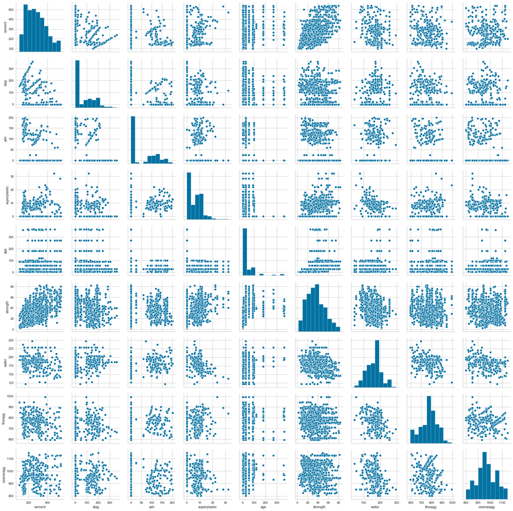

```python
sns.pairplot(mdf)
```

##### Pair-Plot: Observation:

Table Of Contents

- Strength and cement shows a correlation.
- The predictive power score calculated by PPS is difficult to observe from pairplot.
- Skewness in cement , slag , ash , superplastic , age.

### Bivariate Analysis Observation

Table Of Contents

1. I do not see a consistent observation across the PPS, VIF and pairplot - hence we will consider all the columns and their combinations.
2. Age , Slag, Ash and Superplastic will be considered for scaling and normalization.
3. Consider converting age to categorical variables with bins.
4. consider normalizing superplastic and slag column.
5. Ash has gap in teh distribution and requires further investigation.

### Feature Engineering Techniques

Table Of Contents

#### Split The data

Table Of Contents

```python
x = mdf[['cement','slag', 'ash', 'superplastic', 'age','water', 'fineagg', 'coarseagg']].copy()
y = mdf['strength'].copy()

x_train, x_test, y_train, y_test = train_test_split(x, y, test_size = 0.3, random_state = 42)

#we will now work on the train data

x_train_model = x_train.copy()
x_test_model = x_test.copy()
```

#### Slag

Table Of Contents

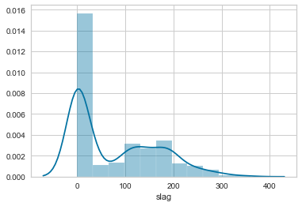

```python
#lets plot the slag column

sns.distplot(x_train_model['slag'])
```

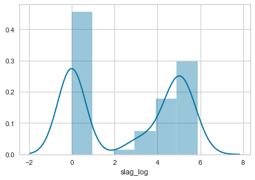

```python
#apply the log transformation
x_train_model['slag_log'] = np.log(x_train_model['slag'] + 1)
sns.distplot(x_train_model['slag_log'])
```

```python
#we define a sigmoid function
def sigmoid(x):
    e = np.exp(1)
    y = 1/(1+e**(-x))
    return y
```

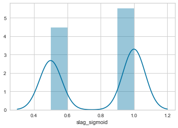

```python
x_train_model['slag_sigmoid'] = sigmoid(x_train_model['slag'])
sns.distplot(x_train_model['slag_sigmoid'])
```

##### observation on transformation

Table Of Contents

1. we see that the log transformtion and sigmoid transformation does not help.
2. we cannot apply box cox transformation as it requires only positive values.
3. we can bin the values to categories and then see the distribution

```python
#let us check with 5 bins
x_train_model['slag'].value_counts(bins = 5)
```

```
(-0.36, 71.88]      395
(143.76, 215.64]    148
(71.88, 143.76]     132
(215.64, 287.52]     33
(287.52, 359.4]      13
Name: slag, dtype: int64
```

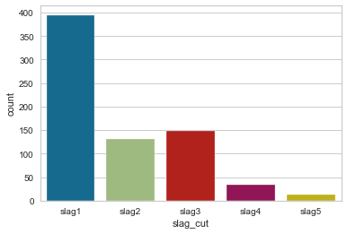

```python
#we will not create a column with 5 bins for slag and check its distribution.

x_train_model['slag_cut'] = pd.cut(x_train_model['slag'], bins = 5 , labels = ['slag1', 'slag2', 'slag3', 'slag4', 'slag5'])

x_train_model['slag_cut'] = x_train_model['slag_cut'].astype('category')

sns.countplot(x_train_model['slag_cut'])
```

```python
#we create a column with the category codes for the above bins

x_train_model['slag_cat'] = x_train_model['slag_cut'].cat.codes
```

#### Ash

Table Of Contents

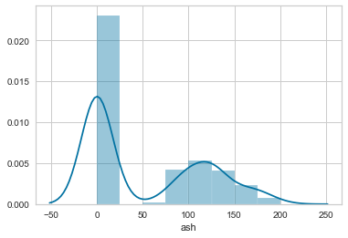

```python
#the follwoing is the distribution
sns.distplot(x_train_model['ash'])
```

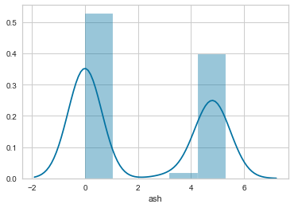

```python
#log transformation does not help in the above situation
sns.distplot(np.log(x_train_model['ash'] + 1))
```

```python
#we see that the lowest value is 0 and the highest is 200.
#let us get the count plot
x_train_model['ash'].value_counts(bins=4)
```

```
(-0.201, 50.025]     416
(100.05, 150.075]    170
(50.025, 100.05]      79
(150.075, 200.1]      56
Name: ash, dtype: int64
```

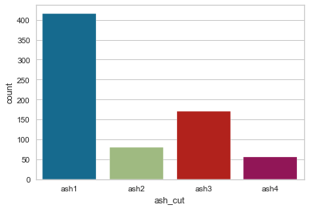

```python
#we will now create a column with 4 bins and check its distribution.
x_train_model['ash_cut'] = pd.cut(x_train_model['ash'], bins = 4, labels = ['ash1', 'ash2', 'ash3', 'ash4'])

sns.countplot(x_train_model['ash_cut'])
```

```python
#we create a column ash_cat with the category codes.
x_train_model['ash_cat'] = x_train_model['ash_cut'].astype('category').cat.codes
```

#### Superplastic

Table Of Contents

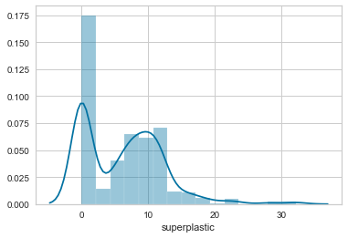

```python
#the follwoing is the distribution
sns.distplot(x_train_model['superplastic'])
```

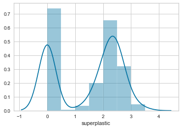

```python
#let us apply log transformation
sns.distplot(np.log(x_train_model['superplastic'] + 1))
```

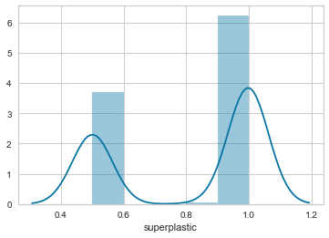

```python
#let us check sigmoid transformation
sns.distplot(sigmoid(x_train_model['superplastic']))
```

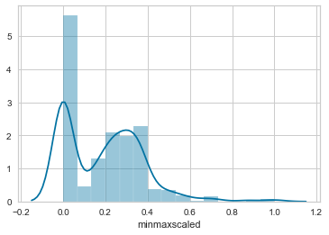

```python
#let us apply minmax scaling
from sklearn.preprocessing import MinMaxScaler
x_train_model['minmaxscaled'] = MinMaxScaler().fit_transform(x_train_model[['superplastic']])
sns.distplot(x_train_model['minmaxscaled'])
```

```python
#let us see the distribution when we bin teh values
x_train_model['superplastic'].value_counts(bins = 6)
```

```
(-0.0332, 5.367]    317
(5.367, 10.733]     234
(10.733, 16.1]      135
(16.1, 21.467]       20
(21.467, 26.833]      8
(26.833, 32.2]        7
Name: superplastic, dtype: int64
```

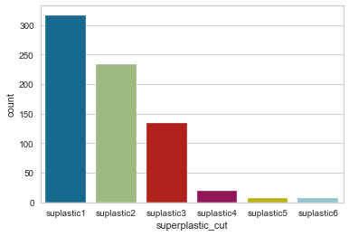

```python
# 6 bins makes the distribution better.

x_train_model['superplastic_cut'] = pd.cut(x_train_model['superplastic'], bins = 6, labels = ['suplastic1', 'suplastic2','suplastic3',
                                                                                'suplastic4', 'suplastic5', 'suplastic6'])

sns.countplot(x_train_model['superplastic_cut'])
```

```python
#we create a column superplastic_cat with the category codes.
x_train_model['superplastic_cat'] = x_train_model['superplastic_cut'].astype('category').cat.codes
```

#### Age

Table Of Contents

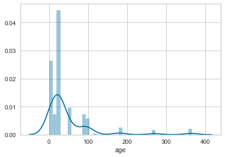

```python
#the follwoing is the distribution
sns.distplot(x_train_model['age'])
```

```python
#let us see the distribution when we bin teh values
x_train_model['age'].value_counts(bins = 5)
```

```
(0.635, 73.8]     589
(73.8, 146.6]      90
(146.6, 219.4]     17
(292.2, 365.0]     14
(219.4, 292.2]     11
Name: age, dtype: int64
```

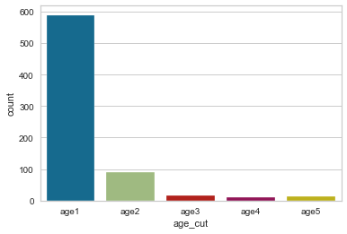

```python
# 5 bins makes the distribution better.

x_train_model['age_cut'] = pd.cut(x_train_model['age'], bins = 5, labels = ['age1', 'age2','age3', 'age4', 'age5'])

sns.countplot(x_train_model['age_cut'])
```

```python
#we create a column age_cat with the category codes.
x_train_model['age_cat'] = x_train_model['age_cut'].astype('category').cat.codes
```

```python
#we check the dtypes
x_train_model.dtypes
```

```
cement               float64
slag                 float64
ash                  float64
superplastic         float64
age                    int64
water                float64
fineagg              float64
coarseagg            float64
slag_log             float64
slag_sigmoid         float64
slag_cut            category
slag_cat                int8
ash_cut             category
ash_cat                 int8
minmaxscaled         float64
superplastic_cut    category
superplastic_cat        int8
age_cut             category
age_cat                 int8
dtype: object
```

```python
#we remove the columns with _cut suffix and other intemediate columns
x_train_model = x_train_model[x_train_model.columns.drop(list(x_train_model.filter(regex='cut', axis = 'columns')))]
x_train_model = x_train_model.drop(['slag_log', 'slag_sigmoid', 'minmaxscaled'], axis = 'columns')
x_train_model.dtypes
```

```
cement              float64
slag                float64
ash                 float64
superplastic        float64
age                   int64
water               float64
fineagg             float64
coarseagg           float64
slag_cat               int8
ash_cat                int8
superplastic_cat       int8
age_cat                int8
dtype: object
```

```python
#we prepare the x_test_model similarly

#for slag
x_test_model['slag_cut'] = pd.cut(x_test_model['slag'], bins = 5 , labels = ['slag1', 'slag2', 'slag3', 'slag4', 'slag5'])
x_test_model['slag_cut'] = x_test_model['slag_cut'].astype('category')
x_test_model['slag_cat'] = x_test_model['slag_cut'].cat.codes


#for ash
x_test_model['ash_cut'] = pd.cut(x_test_model['ash'], bins = 4 , labels = ['ash1', 'ash2', 'ash3', 'ash4'])
x_test_model['ash_cut'] = x_test_model['ash_cut'].astype('category')
x_test_model['ash_cat'] = x_test_model['ash_cut'].cat.codes

#for superplastic
x_test_model['superplastic_cut'] = pd.cut(x_test_model['superplastic'], bins = 6 , labels = ['suplastic1', 'suplastic2','suplastic3',
                                                                                'suplastic4', 'suplastic5', 'suplastic6'])
x_test_model['superplastic_cut'] = x_test_model['superplastic_cut'].astype('category')
x_test_model['superplastic_cat'] = x_test_model['superplastic_cut'].cat.codes


#for age
x_test_model['age_cut'] = pd.cut(x_test_model['age'], bins = 5 , labels = ['age1', 'age2','age3', 'age4', 'age5'])
x_test_model['age_cut'] = x_test_model['age_cut'].astype('category')
x_test_model['age_cat'] = x_test_model['age_cut'].cat.codes
```

```python
x_test_model = x_test_model[x_test_model.columns.drop(list(x_test_model.filter(regex='cut', axis = 'columns')))]
```

```python
#inspect the columns of x_test_model
x_test_model.columns
```

```
Index(['cement', 'slag', 'ash', 'superplastic', 'age', 'water', 'fineagg',
       'coarseagg', 'slag_cat', 'ash_cat', 'superplastic_cat', 'age_cat'],
      dtype='object')
```

### Feature Engineering End Result

Table Of Contents

1. The End dataframes for model building are : **x_train_model, x_test_model, y_train, y_test**
2. The following are the details of the Feature engineering employed:

Column

Transformation

slag

1. Combine the values to 5 bins
2. Convert the column to category
3. Conver the column to categorical type

ash

1. Combine the values to 4 bins
2. Convert the column to category
3. Conver the column to categorical type

superplastic

1. Combine the values to 6 bins
2. Convert the column to category
3. Conver the column to categorical type

Age

1. Combine the values to 5 bins
2. Convert the column to category
3. Conver the column to categorical type

### Model Creation and Tuning

Table Of Contents

#### Introduction

1. Since we need to predict the strenght(continuous variable) and this is a regression problem.
2. we will employ the following set of algorithms :

Algorithms

Hyperparametes

Metrics

Polynomial Regression

1. polynomail Regression - degree
2. interaction_only

R2

Decision Tree Regressor

R2

Bagging Regressor

R2

GradientBoosting Regressor

1. loss
2. learning_rate
3. criterion

R2

```python
#make a list of results from individual Algorithms

resullist = []
bestdecisiontreemodel = ''
```

#### Polynomial Regression Function

Table Of Contents

```python
#we define the function for Polynomial regression

def polyreg(x_train, x_test , y_train, y_test):
    #we define the hyperparameters
    degree = [2, 3 , 4, 5]
    interaction_only = [True , False]

    #instantiate polynomial features :

    polyfeat = PolynomialFeatures()

    linreg = LinearRegression()

    pipe = Pipeline(steps=[('polyfeat', polyfeat), ('linreg', linreg)])

    #we define the param grid for the gridsearchcv:

    param_grid = {
    'polyfeat__degree': degree,
    'polyfeat__interaction_only': interaction_only
    }


    polyregmodel = GridSearchCV(pipe, param_grid, n_jobs=6, cv = 10, iid = False)

    polyregmodel.fit(x_train, y_train)

    y_predict = polyregmodel.predict(x_test)



    return ("PolynomialRegression", polyregmodel.best_params_, r2_score(y_test, y_predict))
```

#### Decision Tree Regression Function

Table Of Contents

```python
def decisionTree(x_train, x_test , y_train, y_test):
    splitter = ['best', 'random']
    max_features = ['auto', 'sqrt', 'log2']
    criterion = ['mse', 'friedman_mse', 'mae']
    max_depth = [2, 3, 5, 10, 15, 20]

    param_dict = dict(splitter = splitter, max_features = max_features, criterion = criterion)

    regressor = DecisionTreeRegressor(random_state = 42)

    bestdecisiontreemodel = GridSearchCV(regressor, param_dict, cv = 10, n_jobs = 6, iid = False)

    bestdecisiontreemodel.fit(x_train, y_train)

    y_dectreepredict = bestdecisiontreemodel.predict(x_test)


    #print("decision Tree: ", r2_score(y_test, y_dectreepredict))

    return ("DecisionTree", bestdecisiontreemodel.best_params_, r2_score(y_test, y_dectreepredict), bestdecisiontreemodel)

    #return bestdecisiontreemodel
```

#### Bagging Regression Function

Table Of Contents

```python
def baggingRegressor(x_train, x_test , y_train, y_test, base_estimator):
    bootstrap = [True]
    n_estimators = [50, 100]
    oob_score = [True]
    max_samples = [.5 , .7]

    param_dict = dict(bootstrap = bootstrap, n_estimators = n_estimators, oob_score = oob_score, max_samples = max_samples)

    #baggregDecTreeinit = BaggingRegressor(base_estimator = base_estimator, n_estimators = 100, bootstrap= True, oob_score = False,  n_jobs = 4, random_state = 42, max_samples = .5)

    baggregDecTreeinit = BaggingRegressor(base_estimator = base_estimator, random_state = 42)

    baggregDecTree = GridSearchCV(baggregDecTreeinit, param_dict, cv = 5, n_jobs = 4, iid = False)

    baggregDecTreemodel = baggregDecTree.fit(x_train, y_train)

    y_baggregdectree = baggregDecTreemodel.predict(x_test)
    #print("Bagging:", r2_score(y_test, y_baggregdectree))

    return ("BaggingRegressor", baggregDecTreemodel.best_params_, r2_score(y_test, y_baggregdectree))
```

#### Boosting Regression Function

Table Of Contents

```python
def gradBoostingRegressor(x_train, x_test , y_train, y_test):
    gradBoostinit = GradientBoostingRegressor(random_state = 42)
    #we also create hyperparameters for penalty:
    learning_rate = [0.1, 0.05]
    n_estimators = [30, 40]
    max_features  = ['auto', 'sqrt', 'log2']
    loss = ['ls', 'lad', 'huber']
    criterion = ['friedman_mse', 'mse', 'mae']
    # Create hyperparameter options
    hyperparameters = dict(learning_rate=learning_rate, max_features = max_features, loss = loss, n_estimators = n_estimators, criterion = criterion)
    # Create grid search using 5-fold cross validation
    gradBoostGridSearch = GridSearchCV(gradBoostinit, hyperparameters, cv = 5, verbose = 0, n_jobs = 3, iid = False)
    gradBoostModel = gradBoostGridSearch.fit(x_train, y_train)

    y_gradBoost = gradBoostModel.predict(x_test)
    #print("gradient Boosting:", r2_score(y_test, y_gradBoost))

    return ("GradientBoosting", gradBoostModel.best_params_, r2_score(y_test, y_gradBoost))
```

```python
#the following is the information about the columns

initial_columns = ['cement', 'slag', 'ash', 'superplastic', 'age', 'water', 'fineagg','coarseagg']

combination_columns = [('age','age_cat'),  ('slag','slag_cat'), ('ash', 'ash_cat'), ('superplastic', 'superplastic_cat')]

modified_columns = ['age_cat', 'slag_cat', 'ash_cat', 'superplastic_cat']
```

```python
#let us get the combination of 2 engineered columns
import itertools
combination_list = list(itertools.combinations(combination_columns,2))
```

```python
#create a list to store the result the result and the best decision tree model

resullist = []
bestdecisiontreemodel = ''
```

#### Main Function for Model Creation and Tuning

Table Of Contents

#### Main Function Introduction

1. We use 2 engineered column at a time.
2. For each set , we iterate through the 4 algorithm using the gridsearch algorithm
3. We calculate the best r2 score and the corresponding values of hyperparameters.
4. This will help us to decide the following :
   - Best 2 engineered columns combination.
   - Best Algorithm
   - Best Set of Parameters.

```python
for columngroup in combination_list:
    col1 = columngroup[0]
    col2 = columngroup[1]
    x_train_itermodel = x_train_model.copy()
    x_train_itermodel = x_train_itermodel[x_train_itermodel.columns.drop([col1[0], col2[0]])]
    list_of_columns_to_be_dropped = list(set(modified_columns) - set([col1[1], col2[1]]))
    x_train_itermodel = x_train_itermodel[x_train_itermodel.columns.drop(list_of_columns_to_be_dropped)]
    x_train_itermodel = x_train_itermodel.rename(columns = lambda x:re.sub('_cat', '', x))


    #perform same steps for test dataframe

    x_test_itermodel = x_test_model.copy()
    x_test_itermodel = x_test_itermodel[x_test_itermodel.columns.drop([col1[0], col2[0]])]
    list_of_columns_to_be_dropped = list(set(modified_columns) - set([col1[1], col2[1]]))
    x_test_itermodel = x_test_itermodel[x_test_itermodel.columns.drop(list_of_columns_to_be_dropped)]
    x_test_itermodel = x_test_itermodel.rename(columns = lambda x:re.sub('_cat', '', x))

    #print("model with :", x_train_itermodel.columns)
    print("model with :", columngroup)

    #calling the regression function

    regresultup = polyreg(x_train_itermodel, x_test_itermodel , y_train, y_test)

    #creating the dictionary of the result from regression

    resreg = {'columns engineered': [col1[0], col2[0]], 'model': regresultup[0], 'best_params': regresultup[1], 'r2score':regresultup[2]}
    print("regression r2: ", regresultup[2])

    #appending the dictionary to the result list.
    resullist.append(resreg)

    #calling the decision tree function
    dectreeresultup = decisionTree(x_train_itermodel, x_test_itermodel , y_train, y_test)

    #creating the dictionary of the result from decision tree
    resdecisiontree = {'columns engineered': [col1[0], col2[0]], 'model': dectreeresultup[0], 'best_params': dectreeresultup[1], 'r2score':dectreeresultup[2] }

    print("Decision Tree r2: ", dectreeresultup[2])

    #getting the best decision tree model
    bestdecisiontreemodel = dectreeresultup[3]

    #appending the result to the result list
    resullist.append(resdecisiontree)


    #getting the best bagging result
    baggingrestup = baggingRegressor(x_train_itermodel, x_test_itermodel , y_train, y_test, bestdecisiontreemodel)

    #creating the dictionary of teh results of bagging algorithm
    resbaggingreg = {'columns engineered': [col1[0], col2[0]], 'model': baggingrestup[0], 'best_params': baggingrestup[1], 'r2score':baggingrestup[2] }

    print("Bagging Regressor r2: ", baggingrestup[2])

    #appending the results to the resultlist
    resullist.append(resbaggingreg)

    #creating the bootstrap regression
    grdBoostrestup = gradBoostingRegressor(x_train_itermodel, x_test_itermodel , y_train, y_test)


    #creting the dictionary of the bootstrap result.
    resBoosting = {'columns engineered': [col1[0], col2[0]], 'model': grdBoostrestup[0], 'best_params': grdBoostrestup[1], 'r2score':grdBoostrestup[2] }

    print("GradientBoosting  r2: ", grdBoostrestup[2])

    #appending to the result list.
    resullist.append(resBoosting)





resullist
```

```
model with : (('age', 'age_cat'), ('slag', 'slag_cat'))
regression r2:  0.5759880095255241
Decision Tree r2:  0.3912146908170696
Bagging Regressor r2:  0.5485052859567685
GradientBoosting  r2:  0.5710588995328444
model with : (('age', 'age_cat'), ('ash', 'ash_cat'))
regression r2:  0.5574945415285779
Decision Tree r2:  0.4070450178296203
Bagging Regressor r2:  0.5471217554972039
GradientBoosting  r2:  0.5418802131390392
model with : (('age', 'age_cat'), ('superplastic', 'superplastic_cat'))
regression r2:  0.5635091477705804
Decision Tree r2:  0.4154094064021222
Bagging Regressor r2:  0.5311915856851944
GradientBoosting  r2:  0.5578338524833555
model with : (('slag', 'slag_cat'), ('ash', 'ash_cat'))
regression r2:  0.855382971132205
Decision Tree r2:  0.7815276891071259
Bagging Regressor r2:  0.8939344403932927
GradientBoosting  r2:  0.8342531057731551
model with : (('slag', 'slag_cat'), ('superplastic', 'superplastic_cat'))
regression r2:  0.8239545348655427
Decision Tree r2:  0.8302729229657131
Bagging Regressor r2:  0.8966118376994628
GradientBoosting  r2:  0.836225486269833
model with : (('ash', 'ash_cat'), ('superplastic', 'superplastic_cat'))
regression r2:  0.73938421164513
Decision Tree r2:  0.8003577809434548
Bagging Regressor r2:  0.8927577990887295
GradientBoosting  r2:  0.8478555330899048
```

[output not shown]

[output cut: 115 more lines]

```
 {'columns engineered': ['ash', 'superplastic'],
  'model': 'BaggingRegressor',
  'best_params': {'bootstrap': True,
   'max_samples': 0.7,
   'n_estimators': 100,
   'oob_score': True},
  'r2score': 0.8927577990887295},
 {'columns engineered': ['ash', 'superplastic'],
  'model': 'GradientBoosting',
  'best_params': {'criterion': 'friedman_mse',
   'learning_rate': 0.1,
   'loss': 'huber',
   'max_features': 'auto',
   'n_estimators': 40},
  'r2score': 0.8478555330899048}]
```

```python
resultDataFrame = pd.DataFrame(resullist)
pd.set_option('display.max_colwidth', -1)
print(resultDataFrame)
```

[output not shown]

[output cut: 74 more lines]

### R2 Score , the Best Model and Observations

Table Of Contents

1. The highest R2 score is 0.8966 or **89%**
2. The algorithm is **Decision tree** with **hyperparameters : Criterion = friedman_mse, max_features = auto, splitter = random.**
3. This algorithm is passed to a **bagging regressor** with **hyperparameters : bootstrap': True, 'max_samples': 0.7, 'n_estimators': 100, 'oob_score': True**

**Observation**

1. We have considered only a subset of possibilities.
2. We only considered combination of 2 engineered columns at a time, there are many other combinations possible.
3. Using the above code , it is possible to use more combinations on a machine with higher computing power to check the best accuracy and best combination.